# Healthcare Application: Heart Disease Prediction

[figure not shown]

# Healthcare Application: Heart Disease Prediction

Kyle Admire, Travis Frocione, Tashuna Jackson, Xenia Liu, Le Nhan, Megan Williams

2023-01-08

## Introduction

**Although it seems easy to maintain a sensible diet, regular exercise, and healthy lifestyle, these are habits that many Americans struggle with.**

**For over a decade, heart disease has been the leading cause of death in the United States, and globally, cardiovascular disease (CVD) is currently the leading cause of death.**

- Every year, about 659,000 people die from heart related illnesses.
- At least three-quarters of the world’s deaths from CVD occur in low and middle-income countries. People living in low and middle-income countries often do not have the benefit of primary healthcare programs for early detection and treatment for risk factors that cause CVD.
- Heart disease, heart attack, stroke, heart failure, arrhythmia, atrial fibrillation, heart valve problems, Etc.

**Depending on the seriousness of your disease, doctors might recommend drugs, surgery, or a combination of the two.**

- Treatment may include: medications, procedures, stenting, ablation, angioplasty, open-heart/bypass surgery, and lifestyle changes such as diet and exercise.
- i.e.: Coronary Artery Bypass Surgery - involves the creation of a graft that allows blood to move around a blocked or constricting coronary artery using a vascular from another region of your body.

## Prediction

**The goal of this study is to create a predictive model that can accurately predict whether or not the patient will contract a cardiovascular disease, before symptoms start occurring.**

**The key performance indicators needing monitoring regularly are: age, gender, diabetes, excess weight, high blood pressure, high cholesterol, physical activity, prior heart attack, yobacco use, family history of heart disease, etc.**

[figure not shown]

Arteries

[figure not shown]

Veins

## Predictive Modeling

#### 1. Logistic Regression Model

Since this classification study is a binary response, a logistic regression model can be employed as to whether or not a patient has a heart disease. The logistic regression model can be written as:

$$\log{\frac{p}{1-p}} = {X^T\beta}$$

where $X$ is the matrix of predictor variables, $\beta$ is the vector of the regression coefficient parameters, and $p$ is the probability that a patient has a heart disease.

```
##               precision    recall  f1-score   support
##
##            0       0.84      0.75      0.79        36
##            1       0.80      0.88      0.83        40
##
##     accuracy                           0.82        76
##    macro avg       0.82      0.81      0.81        76
## weighted avg       0.82      0.82      0.81        76
```

#### 2. Random Forest

A classification tree can also be made to predict whether patients will have a heart disease or not. The classification tree is a sequence of univariate binary partitions of the predictor variables that will improve the accuracy in predicting whether or not patients have the heart disease. In fact, the decision tree is a greedy algorithm, so these partitions are made at each step to minimize the misclassification rate, which is given by:
$$\frac{1}{n}\sum_{i=1}^{n}I(y_i \neq \hat y_i)$$

Where $I(y_i \neq \hat y_i)$ is the indicator function of whether or not each observation’s prediction is correct.

```
##               precision    recall  f1-score   support
##
##            0       0.82      0.75      0.78        36
##            1       0.79      0.85      0.82        40
##
##     accuracy                           0.80        76
##    macro avg       0.80      0.80      0.80        76
## weighted avg       0.80      0.80      0.80        76
```

#### 3. KNN

The K-Nearest Neighbors (KNN) Classifier will also be used to predict whether or not some patients have a heart disease. The KNN Classification model predicts response categories by checking the how the k closest neighbors are classified. The distance that will determine the k nearest neighbors will be euclidean distance of the covariate values. The category that will be predicted will be the same category as the majority of these k closest neighbors. That is, the method for determining the predicted category of any observation $x_0$ is:

$$k = \arg\max_{k\in\{0,1\}}{\sum_{i\in N_0}I(y_i=j)}$$

Where $N_0$ is the set of the k closest neighbors of the observation of $x_0$. Additionally, $k=0$ implies the patient does not have a heart disease and $k=1$ implies the patient does have a heart disease.

```
##               precision    recall  f1-score   support
##
##            0       0.93      0.75      0.83        36
##            1       0.81      0.95      0.87        40
##
##     accuracy                           0.86        76
##    macro avg       0.87      0.85      0.85        76
## weighted avg       0.87      0.86      0.85        76
```

#### 4. SVM

The Support Vector Machine Classifier, or SVM, is an adjustment of the SVC to allow for nonlinear boundaries. To do this, the hyperplane equation is rewritten as:

$$g(x) = \beta_0 + \sum_{i=1}^n \alpha_i K(x,x_i)$$

Where $x$ is any given testing point, and $x_1, ..., x_n$ are the training set observations. Notice that the hyperplane coefficients $\beta_0, \alpha_i$ are now rewritten to represent the individual observations, and a function K. K is a kernel function, which allows the hyperplane to be nonlinear. There are many different commonly used kernels, but the one used is the radial kernel, which is:

$$K(x,x_i) = \exp{[-\gamma\sum_{j=1}^p(x_j - x_{ij})^2]}$$

Where $\sum_{j=1}^p(x_j - x_{ij})^2$ represents the distance between the $x_i$ and the other observations. $\gamma$ is a tuning parameter, which is a measure of how much the boundary is allowed to curve. A larger value of $\gamma$ means that the boundary is more curved. A lower value of $\gamma$ means that the boundary is more straight.

```
##               precision    recall  f1-score   support
##
##            0       0.85      0.78      0.81        36
##            1       0.81      0.88      0.84        40
##
##     accuracy                           0.83        76
##    macro avg       0.83      0.83      0.83        76
## weighted avg       0.83      0.83      0.83        76
```

## Model Evaluation

```
## Model                  R^2 Score    Accuracy
## -------------------  -----------  ----------
## Logistic Regression     0.815789    0.815789
## Random Forest           0.802632    0.802632
## KNN                     0.855263    0.855263
## SVM                     0.828947    0.828947
```

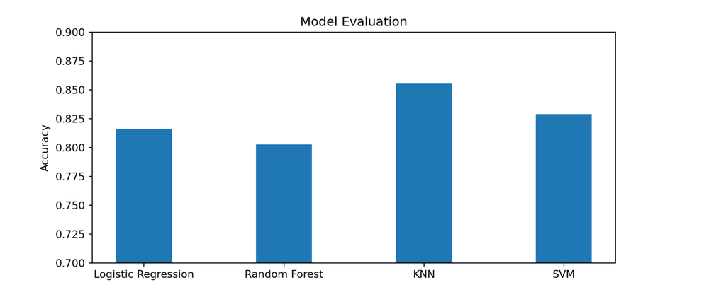

**In the end, the best prediction method is the K-Nearest Neighbors model. In total, the model has 13 predictors, and it was found that k = 7 gives the best results by grid search. If the predictive model can diagnose more unknowing people with heart disease, then doctors can reassess and adjust their clients’ treatments accordingly. As you can see from the chart above, KNN provides the most accurate results.**